# Spline examples

# Simple demo of splines

First generate some pretend data (this will look familiar)

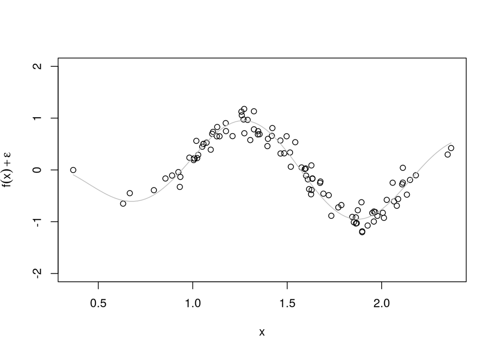

```r
set.seed(3)
true.curve = function(x) {sin(x)*cos(5*x)}
ylim = c(-2,2)
n = 100
x = sort(rnorm(n,1.5,.5))
y = true.curve(x)+rnorm(length(x),0,0.15)
plot(x,y,xlab="x",ylab=expression(f(x)+epsilon),ylim=ylim)
curve(true.curve(x),col="grey",add=TRUE)
```

```r
data = data.frame(x=x,y=y)
```

We can fit splines with `smooth.spline`.

- We can manually specify lambda with `spar` (actually specifies a monotone function of it)
- We can feed the data in as separate `x` and `y` arguments, or as a data frame with `x` and `y` columns

We can predict new values with `predict`.

- To see help file, do `?predict.smooth.spline`
- Takes new `x` values as `x` argument
- Returns data frame with `x` and `y` elements (sorted)

Very low $\lambda$:

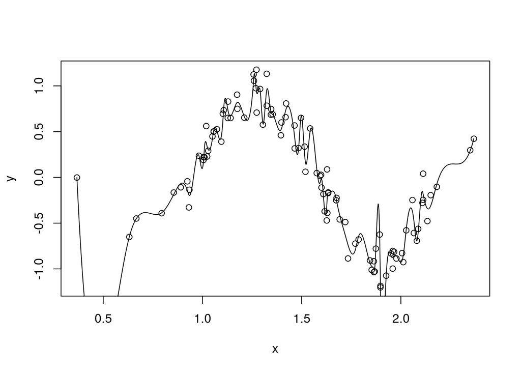

```r
fit_rough = smooth.spline(data,spar = 0)
eval.grid = seq(from=min(data$x),to=max(data$x),length.out=1000)
plot(data)
lines(predict(fit_rough, x=eval.grid))
```

Very high $\lambda$:

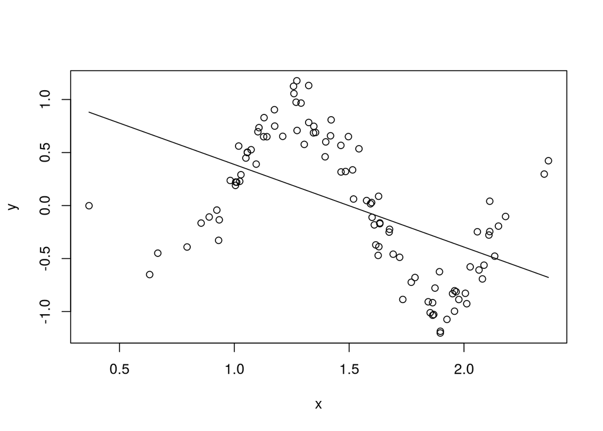

```r
fit_verysmooth = smooth.spline(data,spar=2)
plot(data)
lines(predict(fit_verysmooth, x=eval.grid))
```

Slightly lower, but still very high $\lambda$:

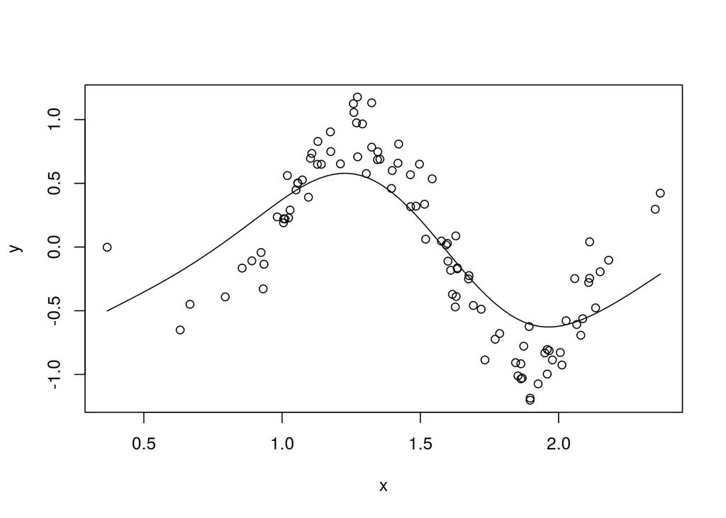

```r
fit_smooth = smooth.spline(data,spar=1)
plot(data)
lines(predict(fit_smooth, x=eval.grid))
```

Cross validated $\lambda$:

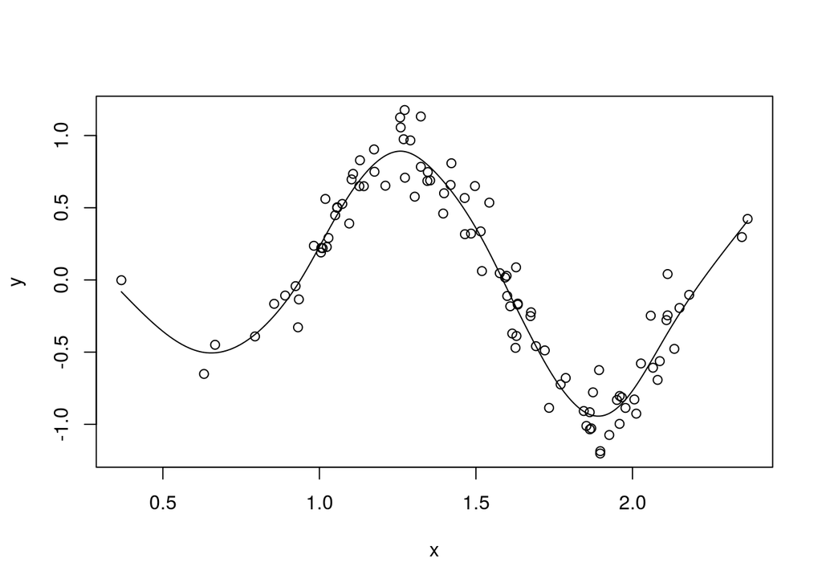

```r
fit_cv = smooth.spline(data)
plot(data)
lines(predict(fit_cv, x=eval.grid))
```

# Fit a spline to financial data

First, we load data from Yahoo finance

- Note, I had problems with this. You can email me if you try to replicate this and also have issues.

```r
require(pdfetch)
sp <- pdfetch_YAHOO("SPY", fields="adjclose",
  from=as.Date("1993-02-09"), to=as.Date("2015-02-09"))
```

```r
# Compute log returns
sp <- diff(log(sp))
# need to drop the initial NA which makes difficulties later
sp <- sp[-1]
```

```r
#All but the last entry
sp.today <- head(sp,-1)
#All but the first entry
sp.tomorrow <- tail(sp,-1)
#Plot tomorrow versus today
plot(as.numeric(sp.today),as.numeric(sp.tomorrow),pch=20,col=rgb(0,0,0,.3))
#Add a nice horizontal line
abline(h=0,lty=3)

#Fit a linear model, see the coefficients
sp.linear = lm(sp.tomorrow ~ sp.today)
coefficients(sp.linear)
```

```
##   (Intercept)      sp.today
##  0.0003386784 -0.0611084550
```

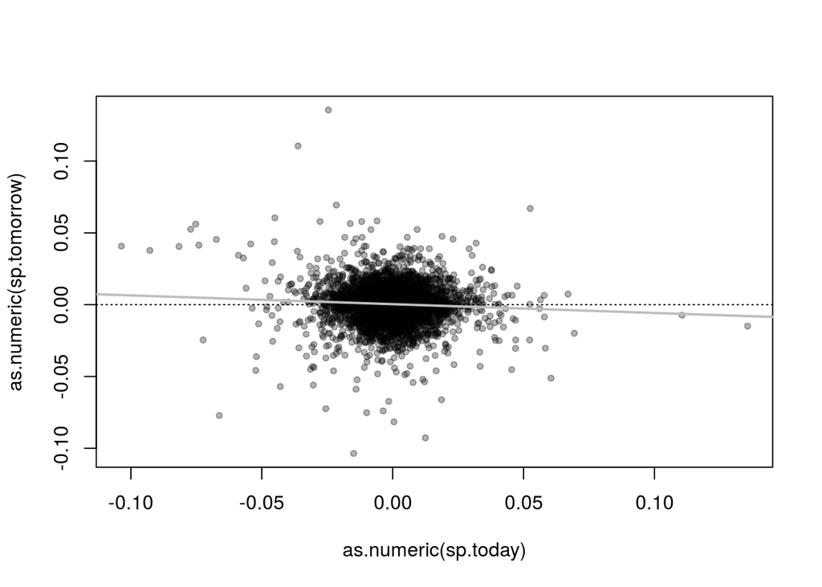

```r
abline(sp.linear,col='grey',lwd=2)
```

We can fit a spline instead of a line:

```r
#Fit a spline
sp.spline <- smooth.spline(x=sp.today,y=sp.tomorrow,cv=TRUE)
sp.spline
```

```
## Call:
## smooth.spline(x = sp.today, y = sp.tomorrow, cv = TRUE)
##
## Smoothing Parameter  spar= 1.329425  lambda= 0.01062264 (11 iterations)
## Equivalent Degrees of Freedom (Df): 6.16281
## Penalized Criterion: 0.8085129
## PRESS: 0.0001412226
```

```r
sp.spline$lambda
```

```
## [1] 0.01062264
```

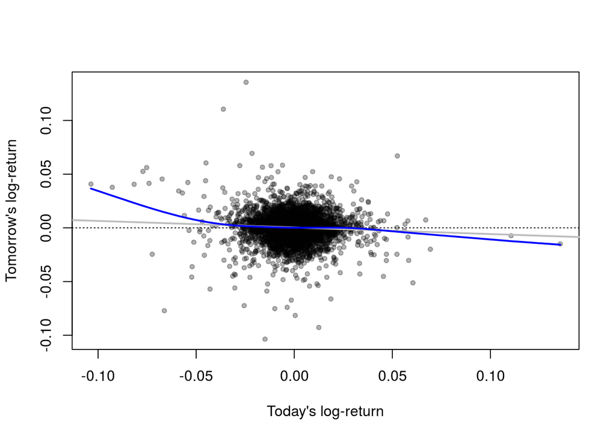

```r
#Plot the spline (and the other stuff)
plot(as.numeric(sp.today),as.numeric(sp.tomorrow),pch=20,col=rgb(0,0,0,.3),xlab="Today's log-return", ylab="Tomorrow's log-return")
abline(h=0,lty=3)
abline(sp.linear,col='grey',lwd=2)
lines(sp.spline,type='l',lwd=2,col='blue') # The spline
```

What happens if we play around with the $\lambda$ parameter:

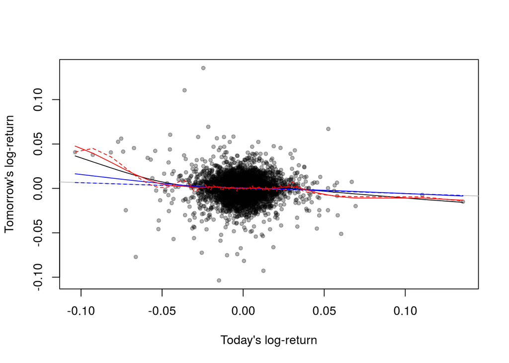

```r
plot(as.numeric(sp.today),as.numeric(sp.tomorrow),pch=20,col=rgb(0,0,0,.3),xlab="Today's log-return", ylab="Tomorrow's log-return")
abline(sp.linear,col="grey")
lines(sp.spline)
lines(smooth.spline(sp.today,sp.tomorrow,spar=1.5),col="blue")
lines(smooth.spline(sp.today,sp.tomorrow,spar=2),col="blue",lty=2)
lines(smooth.spline(sp.today,sp.tomorrow,spar=1.1),col="red")
lines(smooth.spline(sp.today,sp.tomorrow,spar=0.5),col="red",lty=2)
```

# Generate error bounds

We notice that the spline is steeper on the left than on the right! Could this be sampling error? Let’s find bootstrap error bounds on the fit!

First, we build a resampling function to get bootstrap data sets:

```r
# A data frame to hold our data.  Makes it easier to sample rows
sp.frame <- data.frame(today=sp.today,tomorrow=sp.tomorrow)
# A function to sample rows with replacement
sp.resampler <- function() {
  n <- nrow(sp.frame)
  resample.rows <- sample(1:n,size=n,replace=TRUE)
  return(sp.frame[resample.rows,])
}
```

We set up a function to evaluate predictions on an even grid

```r
# Set up a grid of evenly-spaced points on which to evaluate the spline
grid.300 <- seq(from=min(sp.today),to=max(sp.today),length.out=300)

sp.spline.estimator <- function(data,eval.grid=grid.300) {
  # Fit spline to data, with cross-validation to pick lambda
  fit <- smooth.spline(x=data[,1],y=data[,2],cv=TRUE)
  # Do the prediction on the grid and return the predicted values
  return(predict(fit,x=eval.grid)$y)  # We only want the predicted values
}
```

A function to draw $B$ bootstrap samples and compute pointwise quantiles:

```r
sp.spline.cis <- function(B,alpha,eval.grid=grid.300) {
  spline.main <- sp.spline.estimator(sp.frame, eval.grid=eval.grid)
  # Draw B boottrap samples, fit the spline to each
  # Result has length(eval.grid) rows and B columns
  spline.boots <- replicate(B, sp.spline.estimator(sp.resampler(),eval.grid=eval.grid))
  cis.lower <- 2*spline.main - apply(spline.boots,1,quantile,probs=1-alpha/2)
  cis.upper <- 2*spline.main - apply(spline.boots,1,quantile,probs=alpha/2)
  return(list(main.curve=spline.main, lower.ci=cis.lower, upper.ci=cis.upper, x=eval.grid))
}
```

Now we run it all together!

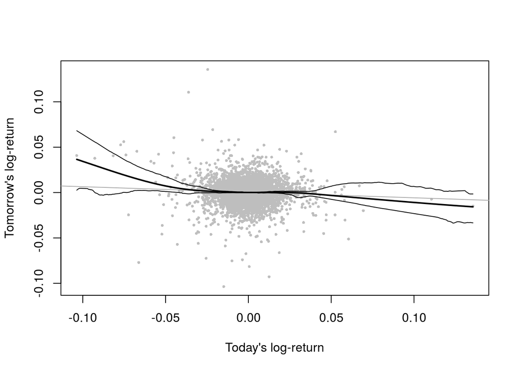

```r
#Get the confidence intervals
sp.cis <- sp.spline.cis(B=1000,alpha=0.05)
#Plot the confidence intervals
plot(as.vector(sp.today),as.vector(sp.tomorrow),xlab="Today's log-return",
  ylab="Tomorrow's log-return",pch=16,cex=0.5,col="grey")
abline(sp.linear,col="darkgrey")
lines(x=sp.cis$x,y=sp.cis$main.curve,lwd=2)
lines(x=sp.cis$x,y=sp.cis$lower.ci)
lines(x=sp.cis$x,y=sp.cis$upper.ci)
```